# Fórmulas Bioestadística

## **Estadística descriptiva**

**Media aritmética**

$$\bar{x} = \mu = \frac{1}{n} \sum_{i=1}^{n} x_i$$

donde:

- $\bar{x} = \mu$ : media aritmética
- $n$ : número de muestras
- $i$ : índice de los valores de la variable ($i = 1, 2, \dots, n$)
- $x_i$ : valor $i$-ésimo de la variable $x$

**Mediana**

- Para un número **impar** de observaciones ($n$):

$$\text{mediana}(x) = \left(\frac{n+1}{2}\right)^{\text{th}}$$

- Para un número **par** de observaciones:

$$\text{mediana}(x) = \frac{\left(
{\left(\tfrac{n}{2}\right)}^{\text{th}} +
{\left(\tfrac{n}{2}+1\right)}^{\text{th}}\right)
}{2}$$

donde:

- $\text{mediana}(x)$: mediana de los valores disponibles de la variable $x$
- $n$: número de observaciones disponibles para $x$

**Moda**

$$moda(x)=max_{k=1}(I_{i=1}(x_i=x_k))$$

donde:

- $\text{moda}(x)$: moda de los valores disponibles de la variable $x$
- $\max_{k=1}()$: argumento que maximiza sobre $k$ en $1$ a $p$
- $I_i()$: función indicadora que devuelve 1 si la condición interna es cierta para $i$ en $1$ a $n$

**Rango**

Diferencia entre el valor máximo y el mínimo de una variable $x$:

$$rango = x_{\text{max}} - x_{\text{min}}$$

**Varianza**

$$s^2 = \frac{1}{n-1} \sum_{i=1}^{n} (x_i - \bar{x})^2$$

donde:

- $s^2$: varianza
- $n$: número de observaciones de la muestra
- $i$: índice de los valores de la variable ($i = 1, 2, \dots, n$)
- $x_i$: valor $i$-ésimo de la variable $x$
- $\bar{x}$: media aritmética

**Desviación estándard**

$$SD = s = \sqrt{s^2}$$

donde:

- $SD = s$: desviación estándar
- $s^2$: varianza

**Cuantiles**

| Nombre | Símbolo | Porcentaje de los datos | Interpretación |
| --- | --- | --- | --- |
| Primer cuartil | $Q_1$ | 25% | El 25% de los datos son menores o iguales que este valor |
| Segundo cuartil (mediana) | $Q_2$ | 50% | El 50% de los datos son menores o iguales que este valor |
| Tercer cuartil | $Q_3$ | 75% | El 75% de los datos son menores o iguales que este valor |

**Rango intercuartílico**

$$IQR=Q_3-Q_1$$

*Outliers*

$$\text{Cerca inferior} = Q_1 - 1.5 \times IQR$$

$$\text{Cerca superior} = Q_3 + 1.5 \times IQR$$

## **Distribuciones**

**Asimetría**

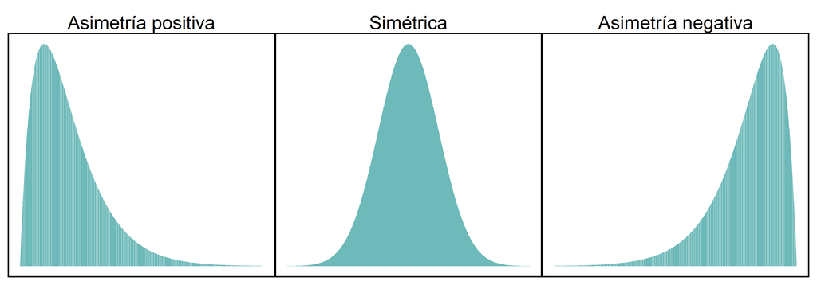

**Curtosis**

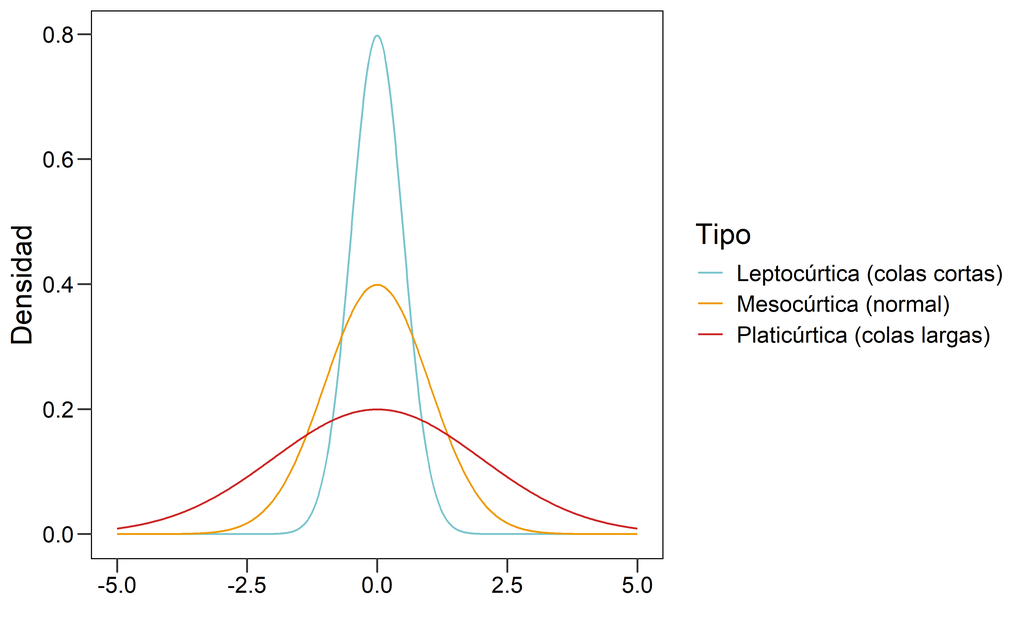

## **Distribución binomial**

**Fórmula de la distribución binomial**

$$P(X = k) = \binom{n}{k} p^k (1-p)^{n-k}$$

donde:

- $n$: número total de ensayos o repeticiones del experimento
- $k$: número de éxitos observados
- $p$: probabilidad de éxito en un solo ensayo
- $1 - p$: probabilidad de fracaso

**Coeficiente binomial**

$${n \choose k} \;=\; \frac{n!}{k!\,(n - k)!}$$

donde:

- $n = 1, 2, \dots$: número total de ensayos
- $k = 0, 1, 2, \dots , n$: número de éxitos posibles
- Para cualquier número entero $m$, $m! = m \times (m - 1) \times (m - 2) \times \dots \times 1$

**Tabla resumen de la binomial**

| Símbolo | Significado | Expresión |
| --- | --- | --- |
| $P(X \le k)$ | “como mucho k” | $P(X \le k)$ |
| $P(X < k)$ | “menos de k” | $P(X \le k-1)$ |
| $P(X \ge k)$ | “al menos k” | $1 - P(X \le k-1)$ |
| $P(X > k)$ | “más de k” | $1 - P(X \le k)$ |

Si la variable aleatoria sigue una distribución $X \sim \text{Binomial}(n, p)$, entonces:

- **Media**
  $$\mu = n \times p$$
- **Varianza**
  $$\sigma^2 = n \times p \times (1 - p)$$

## **Distribución normal**

Si la variable aleatoria sigue una distribución $X \sim N(\mu, \sigma^2)$, entonces:

- $\mu$ representa la **media**
- $\sigma$ representa la **desviación estándar**

**Estandarización**

Si una variable aleatoria $X$ sigue una distribución normal con media $\mu$ y varianza $\sigma^2$, $X \sim N(\mu,\ \sigma^2)$, entonces la variable estandarizada:

$$Z = \frac{X - \mu}{\sigma}$$

sigue una distribución normal estándar: $Z \sim N(0,1)$.

**Tabla resumen de la normal**

| Símbolo | Significado | Expresión |
| --- | --- | --- |
| $P(X \le x)$ | “como mucho x” | $P(X \le x)$ |
| $P(X < x)$ | “menos de x” | $P(X \le x)$ (igual, continua) |
| $P(X \ge x)$ | “al menos x” | $1 - P(X \le x)$ |
| $P(X > x)$ | “más de x” | $1 - P(X \le x)$ |
| $P(a \le X \le b)$ | “entre a y b” | $P(X \le b) - P(X \le a)$ |
| $P(a < X < b)$ | “entre a y b” | $P(X \le b) - P(X \le a)$ (igual, continua) |

**Regla empírica (“68-95-99.7”)**:

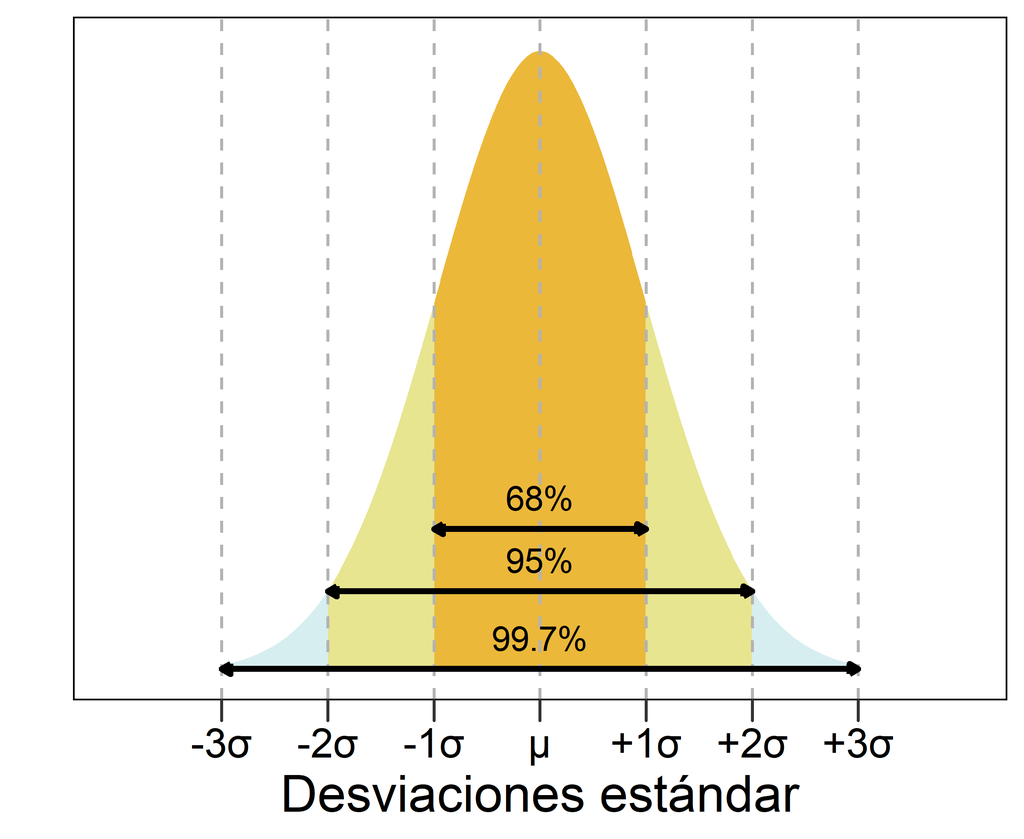

- ~68% de los valores dentro de 1 desviación estándar de la media
- ~95% dentro de 2 desviaciones estándar
- ~99.7% dentro de 3 desviaciones estándar

## **Distribución de Poisson**

**Fórmula de la distribución de Poisson**

$$P(X = k) = \frac{ e^{-\lambda} \lambda^k}{k!}$$

donde:

- $X$: número de eventos en un intervalo dado
- $\lambda$: tasa esperada de eventos en ese intervalo ($n \times p$)
- $k$: número de eventos observados

Si la variable aleatoria sigue una distribución de Poisson $X \sim \text{Poisson}(\lambda)$, entonces:

- $\lambda$ representa tanto la media como el parámetro de la distribución: $\mu = \lambda$
- La desviación estándar es: $\sigma = \sqrt{\lambda}$

La probabilidad de exáctamente $x$ eventos en $t$ unidades de tiempo es:

$$P(X = k) = \frac{e^{-\lambda t} (\lambda t)^k }{k!}$$

En $t$ unidades de tiempo, la media es $\mu = \lambda t$ y desviación estandard $\sigma = \sqrt{\lambda t}$.

**Tabla resumen de la distribución de Poisson**

| Símbolo | Significado | Expresión |
| --- | --- | --- |
| $P(X \le k)$ | “como mucho k” | $P(X \le k)$ |
| $P(X < k)$ | “menos de k” | $P(X \le k-1)$ |
| $P(X \ge k)$ | “al menos k” | $1 - P(X \le k-1)$ |
| $P(X > k)$ | “más de k” | $1 - P(X \le k)$ |

## **Tabla resumen de las distribuciones**

|  | Binomial | Normal | Poisson |
| --- | --- | --- | --- |
| Parámetros | $n$, $p$ | $μ$, $σ$ | $λ$ |
| Valores posibles | $0, 1, ..., n$ | $(-∞, ∞)$ | $0, 1, ..., ∞$ |
| Media | $np$ | $\mu$ | $\lambda$ |
| Desviación estándard | $\sqrt{np(1-p)}$ | $σ$ | $\sqrt{\lambda}$ ($\sqrt{\lambda t}$) |

## **Intervalos de confianza**

**Desviación estándar de la distribución muestral [error estándar (SE)]**

$$\sigma_{\bar{X}} = SE = \frac{\sigma}{\sqrt{n}}$$

Si solo tienes la desviación estándar muestral, entonces:

$$SE = \frac{s}{\sqrt{n}}$$

**Intervalo de confianza (CI)**

$$CI = \bar{x} \pm z \times \frac{\sigma}{\sqrt{n}}$$

donde:

- $\bar{x}$ = media muestral
- $z$ = valor crítico según el nivel de confianza (por ejemplo, 1.96 para 95%)
- $\sigma/\sqrt{n}$ = error estándar de la media

Cuando estimamos una media poblacional $\mu$, un intervalo de confianza tiene la forma general:

$$(\bar{x} - m, \bar{x} + m) = \bar{x} \pm m$$

donde:

- $m$: **margen de error**

El margen de error $m$ se define como:

$$m=z_{\alpha/2}\times\frac{\sigma}{\sqrt{n}}$$

A partir de la **media muestral** $\bar{x}$ y el **error**, podemos calcular:

$$IC = (\bar{x} - \text{error}, \bar{x} + \text{error})$$

donde el error se calcula como:

$$\text{error} = z_{\alpha/2} \cdot \frac{\sigma}{\sqrt{N}}$$

- $z_{\alpha/2}$: valor crítico según el nivel de confianza deseado
- $\sigma$: desviación estándar poblacional
- $N$: tamaño de la muestra

Por lo tanto, los límites del IC son:

$$x_1 = \bar{x} - z_{\alpha/2} \frac{\sigma}{\sqrt{N}}, \quad
x_2 = \bar{x} + z_{\alpha/2} \frac{\sigma}{\sqrt{N}}$$

**Fórmula para el tamaño de la muestra**

$$N = \left(\frac{z_{\alpha/2} \times \sigma}{\text{error
deseado}}\right)^2$$

**Intervalos de confianza unilaterales (*one-sided*)**

- Proporcionan **un límite inferior o un límite superior**, pero **no ambos**.
- Forma general:

$$(-\infty, \bar{x} + \text{error}) \quad \text{o} \quad (\bar{x} -
\text{error}, \infty)$$

- Se utiliza **el error estándar (SE)** y un valor $z$ crítico, pero el $z$ **es distinto** que para intervalos bilaterales.

**Estadístico z para una media muestral**

$$z = \frac{\bar{x} - \mu}{\sigma / \sqrt{n}}$$

donde:

- $\bar{x}$ = media muestral
- $\mu$ = media poblacional bajo $H_0$
- $\sigma$ = desviación estándar poblacional
- $n$ = tamaño de la muestra

## **T-test**

**Tablas resumen para t-test**

| Tipo de t-test | Estadístico t | Grados de libertad (df) | Intervalo de confianza (IC) |
| --- | --- | --- | --- |
| **1 muestra** | $t = \frac{\bar{x}-\mu_0}{s/\sqrt{n}}$ | $n-1$ | $\bar{x} \pm t_{df} \frac{s}{\sqrt{n}}$ |
| **Pareado** | $t = \frac{\bar{x}_{dif}}{s_{dif}/\sqrt{n}}$ | $n-1$ | $\bar{x}_{dif} \pm t_{df} \frac{s_{dif}}{\sqrt{n}}$ |
| **2 muestras independientes** | $t = \frac{\bar{x}_1 - \bar{x}_2}{\sqrt{s^2_1/n_1 + s^2_2/n_2}}$ | $n_1 + n_2 - 2$ | $(\bar{x}_1 - \bar{x}_2) \pm t_{df} \sqrt{s^2_1/n_1 + s^2_2/n_2}$ |

| Tipo de t-test | Hipótesis nula ($H_0$) | Hipótesis alternativa ($H_A$) |
| --- | --- | --- |
| **1 muestra** | $\mu = \mu_0$ | $\mu \ne \mu_0$ |
| **Pareado** | $\mu_{dif} = 0$ | $\mu_{dif} \ne 0$ |
| **2 muestras independientes** | $\mu_1 = \mu_2$ | $\mu_1 \ne \mu_2$ |

| Tipo de test | Hipótesis | IC / Zona crítica | Interpretación |
| --- | --- | --- | --- |
| **Bilateral (dos colas)** | $H_0: \mu = \mu_0$ $H_A: \mu \ne \mu_0$ | $IC = \bar{x} \pm \|t_{crit}\| \times SE$ | IC simétrico alrededor de $\bar{x}$. Si $\mu_0$ **no está dentro**, se rechaza $H_0$. |
| **Unilateral (cola derecha)** | $H_0: \mu = \mu_0$ $H_A: \mu > \mu_0$ | $IC = (\bar{x} - \|t_{crit}\| \times SE, +\infty)$ | Si límite inferior > $\mu_0$, se rechaza $H_0$. |
| **Unilateral (cola izquierda)** | $H_0: \mu = \mu_0$ $H_A: \mu < \mu_0$ | $IC = (-\infty, \bar{x} + \|t_{crit}\| \times SE)$ | Si límite superior < $\mu_0$, se rechaza $H_0$. |

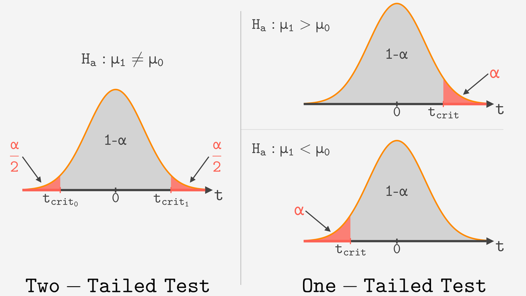

## **ANOVA**

#### ANOVA de una vía

| Fuente de variación | Suma de cuadrados (SS) | Grados de libertad (gl) | Media cuadrática (MS) | Estadístico F |
| --- | --- | --- | --- | --- |
| **Factor** (variabilidad entre grupos) | $SS_{entre} = \displaystyle \sum_{i=1}^{g} n_i (M_i - G)^2$ | $gl_{entre} = g - 1$ | $MS_{entre} = \dfrac{SS_{entre}}{gl_{entre}}$ | $F = \dfrac{MS_{entre}}{MS_{dentro}}$ |
| **Residuos** (variabilidad dentro de los grupos) | $SS_{dentro} = \displaystyle \sum_{i=1}^{g} \sum_{j=1}^{n_i} (x_{ij} - M_i)^2$ | $gl_{dentro} = N - g$ | $MS_{dentro} = \dfrac{SS_{dentro}}{gl_{dentro}}$ |  |
| **Total** | $SS_{total} = \displaystyle \sum_{i=1}^{g} \sum_{j=1}^{n_i} (x_{ij} - G)^2$ | $gl_{total} = N - 1$ |  |  |

**Donde:**

- $G$ = media global (media conjunta de todos los grupos)
- $M_i$ = media del grupo *i*
- $n_i$ = tamaño del grupo *i*
- $g$ = número de grupos
- $N$ = número total de observaciones

#### ANOVA de dos vías

| Fuente de variación | Suma de cuadrados (SS) | Grados de libertad (gl) | Media cuadrática (MS) | Estadístico F |
| --- | --- | --- | --- | --- |
| **Factor A** | $SS_{A}=n\times p\times \sum(\bar{A}_i-\bar{G})^2$ | $gl_A = p - 1$ | $MS_A = \dfrac{SS_A}{gl_A}$ | $F_A = \dfrac{MS_A}{MS_E}$ |
| **Factor B** | $SS_{B}=n\times q\times \sum(\bar{B}_i-\bar{G})^2$ | $gl_B = q - 1$ | $MS_B = \dfrac{SS_B}{gl_B}$ | $F_B = \dfrac{MS_B}{MS_E}$ |
| **Entre grupos** | $SS_{btw}=n\times\sum\sum(\bar{X}_{ij}-\bar{G})^2$ | $gl_{btw} = p \times q - 1$ | $MS_B = \dfrac{SS_{btw}}{gl_{btw}}$ |  |
| **Interacción A×B** | $SS_{A:B}=SS_{btw}-SS_{A}-SS_{B}$ | $gl_{AB} = (p-1)(q-1)$ | $MS_{AB} = \dfrac{SS_{A:B}}{gl_{AB}}$ | $F_{A:B} = \dfrac{MS_{A:B}}{MS_E}$ |
| **Residuos (Error)** | $SS_{error}=\sum\sum\sum(x_{mij}-\bar{AB}_{ij})^2$ | $gl_E = (n-1)\times p \times q$ | $MS_E = \dfrac{SS_E}{gl_E}$ |  |
| **Total** | $SS_{total}=\sum\sum\sum(x_{mij}-\bar{G})^2$ | $gl_T = n\times p \times q-1$ |  |  |

**Donde:**

- $n$: total de observaciones
- $p$: número de grupos en el factor A
- $q$: número de grupos en el factor B
- $\bar{G}$ = media global de todas las observaciones
- $\bar{A}_i$ = media de cada nivel del factor A
- $\bar{B}_i$ = media de cada nivel del factor B
- $\bar{AB}_{ij}$: media de cada combinación de niveles de A × B.

| Tipo de ANOVA | Descomposición | Componentes | R² |
| --- | --- | --- | --- |
| **Una vía** | $SS_{total} = SS_{entre} + SS_{dentro}$ | 1 factor | $R^2 = SS_{entre} / SS_{total}$ o $R^2 = 1 - SS_{res}/SS_{total}$ |
| **Dos vías** | $SS_{total} = SS_A + SS_B + SS_{A:B} + SS_{error}$ | 2 factores + interacción | $R^2 = (SS_A + SS_B + SS_{A:B}) / SS_{total}$ o $R^2 = 1 - SS_{res}/SS_{total}$ |

## **Coeficiente de correlación de Pearson**

$r = \frac{\sum_{i=1}^{n}(x_i - \bar{x})(y_i - \bar{y})}{\sqrt{\sum_{i=1}^{n}(x_i - \bar{x})^2} \, \sqrt{\sum_{i=1}^{n}(y_i - \bar{y})^2}}$

donde:

- $r$: coeficiente de correlación de Pearson
- $x_i$: valores individuales de la variable $x$
- $y_i$: valores individuales de la variable $y$
- $\bar{x}$: media de la variable $x$
- $\bar{y}$: media de la variable $y$

## **Correlación de Spearman**

$r_s = 1 - \frac{6 \sum d_i^2}{n(n^2 - 1)}$

donde:

- $r_s$ es el coeficiente de correlación de Spearman
- $n$ es el número de pares de datos
- $d_i = R(X_i) - R(Y_i)$ es la diferencia entre los rangos del i-ésimo par de valores
- $\sum_{i=1}^{n} d_i^2$ es la suma de los cuadrados de las diferencias de rangos

**Test del coeficiente de correlación**

$t = \frac{r \sqrt{n-2}}{\sqrt{1-r^2}}$

- $r$: coeficiente de correlación de la muestra
- $n$: tamaño de la muestra
- El **p-valor** se calculará usando la distribución `t` con $n-2$ grados de libertad

## **τ de Kendall**

$\tau = \frac{(n_c - n_d)}{n_c+n_d}$

donde:

- $n_c$: número de pares **concordantes**
- $n_d$: número de pares **discordantes**

**Test del coeficiente de τ de Kendall**

$z = \frac{3\tau\sqrt{n(n-1)}}{\sqrt{2(2n + 5)}}$

## **Chi-cuadrado**

$\chi^2 = \sum \frac{(O - E)^2}{E}$

$gl = (r - 1)(c - 1)$

donde:

- $r$ es el número de filas
- $c$ es el número de columnas

## **Test exacto de Fisher**

Para una tabla de contingencia $2 \times 2$:

$\begin{array}{c|cc|c} & \text{Éxito} & \text{Fracaso} & \text{Total} \\ \hline \text{Grupo A} & a & b & a + b \\ \text{Grupo B} & c & d & c + d \\ \hline \text{Total} & a + c & b + d & n \end{array}$

La probabilidad exacta de observar esta tabla viene dada por la distribución hipergeométrica:

$P = \frac{\binom{a+b}{a}\binom{c+d}{c}}{\binom{n}{a+c}}$

## *Odds ratio*

$OR=\frac{\frac{a}{b}}{\frac{c}{d}}=\frac{ad}{bc}$

## **D de Cohen**

$d = \frac{\bar{X}_1-\bar{X}_2}{s_p}$

donde

$s_p=\sqrt{\frac{(n_1-1)s^2_1+(n_2-1)s^2_2}{n_1+n_2-2}}$

## **Teorema de Bayes**

$p(θ|d) = \frac{p(d|θ)p(θ)}{p(d)}$

donde:

- $p(θ|d)$: *posterior prob.*
- $p(d|θ)$: *verosimilitud likelihood*
- $p(θ)$: *prior*
- $p(d)$: constante normalizadora o probabilidad marginal

$p(θ|d) ∝ p(d|θ)p(θ)$: *unscaled prior*

**Bayes Factor**

$BF_{10}\frac{P(datos|H_1)}{P(datos|H_0)}$